# LMA

Wei Li, Florence Yan, Ziyu Jin

January 30, 2019

```r
library(tidyverse)
library(ggplot2)
```

# Data preparation

```r
### Load data
wa_data <- read.csv('ss16pwa.csv')
### Subset and focus on the data of interest
# SERIALNO: Housing unit/GQ person serial number
# SPORDER: Person number
# SEX: Sex
# CIT: Citizenip status
# PERNP: Total person's earnings
# SCHL: Educational attainment
# RAC1P: Recoded detailed race code
# ESR: Employment status
research_data <- wa_data[c('SERIALNO','SPORDER','SEX', 'CIT','PERNP','SCHL','RAC1P','ESR', 'MAR')]
summary(research_data)
```

```
##     SERIALNO          SPORDER            SEX             CIT
##  Min.   :     75   Min.   : 1.000   Min.   :1.000   Min.   :1.000
##  1st Qu.: 383734   1st Qu.: 1.000   1st Qu.:1.000   1st Qu.:1.000
##  Median : 761701   Median : 2.000   Median :2.000   Median :1.000
##  Mean   : 761171   Mean   : 2.084   Mean   :1.506   Mean   :1.444
##  3rd Qu.:1142120   3rd Qu.: 3.000   3rd Qu.:2.000   3rd Qu.:1.000
##  Max.   :1521404   Max.   :14.000   Max.   :2.000   Max.   :5.000
##
##      PERNP             SCHL          RAC1P           ESR
##  Min.   : -5100   Min.   : 1.0   Min.   :1.00   Min.   :1.00
##  1st Qu.:     0   1st Qu.:15.0   1st Qu.:1.00   1st Qu.:1.00
##  Median : 14000   Median :18.0   Median :1.00   Median :1.00
##  Mean   : 33897   Mean   :16.4   Mean   :2.13   Mean   :3.08
##  3rd Qu.: 48000   3rd Qu.:21.0   3rd Qu.:1.00   3rd Qu.:6.00
##  Max.   :850000   Max.   :24.0   Max.   :9.00   Max.   :6.00
##  NA's   :13270    NA's   :2317                  NA's   :13270
##       MAR
##  Min.   :1.000
##  1st Qu.:1.000
##  Median :3.000
##  Mean   :2.873
##  3rd Qu.:5.000
##  Max.   :5.000
##
```

# Data cleaning

```r
# exclude all missing values
new <- na.exclude(research_data)
# exclude those who cannot work due to age under 16 years old or not in labor force.
new <- new[new['ESR'] != 6, ]
```

```r
## group educational attainment levels into 5 levels:
# A: with degrees no higher than high school;
# B: with colleage degree;
# C: with professional degree;
# D: with master degree;
# E: with Doctor degree
for (rows in 1:nrow(new)) {
  if (new[rows, 'SCHL'] <= 19) {
    new[rows, 'EducLevel'] = 'A'
  }
  if (new[rows, 'SCHL'] >= 20 & new[rows, 'SCHL'] <= 21) {
    new[rows, 'EducLevel'] = 'B'
  }
  if (new[rows, 'SCHL'] == 23) {
    new[rows, 'EducLevel'] = 'C'
  }
  if (new[rows, 'SCHL'] == 22) {
    new[rows, 'EducLevel'] = 'D'
  }
  if (new[rows, 'SCHL'] == 24) {
    new[rows, 'EducLevel'] = 'E'
  }
}
```

```r
# Redefine variable citizenship
# 1: US Citizen
# 2: Not US Citizen
for (rows in 1:nrow(new)) {
  if (new[rows, 'CIT'] != 5) {
    new[rows, 'CIT'] = 1
  }
  if (new[rows, 'CIT'] == 5) {
    new[rows, 'CIT'] = 2
  }
}
```

```r
# Redefine marrige status:
# 1: In marrige now
# 2: Not in marrige now
for (rows in 1:nrow(new)) {
  if (new[rows, 'MAR'] == 1 ) {
    new[rows, 'MAR'] = 1
  }
  if (new[rows, 'MAR'] != 1) {
    new[rows, 'MAR'] = 2
  }
}
```

```r
# Columns name change
new <- new[c("SERIALNO", "SPORDER","SEX", "CIT", "PERNP", "RAC1P", "EducLevel", "MAR")]
colnames(new) <- c("Housing_Unit","Person_Number", "Sex", "Citizenship", "Total_Person_Earning", "Race", "EducLevel", "Marrige")

# Change the data type
new$Citizenship <- as.factor(new$Citizenship)
new$Sex <- as.factor(new$Sex)
new$Race <- as.factor(new$Race)
new$EducLevel <- as.factor(new$EducLevel)
new$Marrige <- as.factor(new$Marrige)

summary(new)
```

```
##   Housing_Unit     Person_Number  Sex       Citizenship
##  Min.   :    142   Min.   : 1.0   1:19107   1:33164
##  1st Qu.: 386128   1st Qu.: 1.0   2:16581   2: 2524
##  Median : 763680   Median : 1.0
##  Mean   : 763177   Mean   : 1.7
##  3rd Qu.:1143351   3rd Qu.: 2.0
##  Max.   :1521404   Max.   :14.0
##
##  Total_Person_Earning      Race       EducLevel Marrige
##  Min.   : -5100       1      :28266   A:18661   1:20273
##  1st Qu.: 19000       6      : 2880   B:12123   2:15415
##  Median : 40000       9      : 1438   C:  823
##  Mean   : 54859       8      : 1255   D: 3519
##  3rd Qu.: 70000       2      : 1018   E:  562
##  Max.   :850000       3      :  554
##                       (Other):  277
```

# Data modeling

```r
mod <- lm(Total_Person_Earning ~ EducLevel + Sex + Citizenship + Race + Marrige, data = new)
summary(mod)
```

```
##
## Call:
## lm(formula = Total_Person_Earning ~ EducLevel + Sex + Citizenship +
##     Race + Marrige, data = new)
##
## Residuals:
##     Min      1Q  Median      3Q     Max
## -163750  -28723   -9004   14451  813451
##
## Coefficients:
##              Estimate Std. Error t value Pr(>|t|)
## (Intercept)   60723.1      619.2  98.070  < 2e-16 ***
## EducLevelB    24258.1      694.6  34.925  < 2e-16 ***
## EducLevelC    97926.7     2091.6  46.819  < 2e-16 ***
## EducLevelD    44249.3     1091.9  40.525  < 2e-16 ***
## EducLevelE    62662.3     2511.2  24.953  < 2e-16 ***
## Sex2         -24173.9      622.8 -38.815  < 2e-16 ***
## Citizenship2  -5094.6     1316.9  -3.869 0.000110 ***
## Race2        -11598.9     1868.5  -6.208 5.44e-10 ***
## Race3         -7849.4     2513.4  -3.123 0.001792 **
## Race4         -9515.2    10854.2  -0.877 0.380688
## Race5         -4251.8     7747.5  -0.549 0.583149
## Race6          4072.7     1192.6   3.415 0.000638 ***
## Race7         -9822.9     4250.1  -2.311 0.020827 *
## Race8        -13390.0     1789.7  -7.482 7.51e-14 ***
## Race9         -5976.7     1583.8  -3.774 0.000161 ***
## Marrige2     -21341.5      638.3 -33.436  < 2e-16 ***
## ---
## Signif. codes:  0 '***' 0.001 '**' 0.01 '*' 0.05 '.' 0.1 ' ' 1
##
## Residual standard error: 58410 on 35672 degrees of freedom
## Multiple R-squared:  0.1885, Adjusted R-squared:  0.1882
## F-statistic: 552.4 on 15 and 35672 DF,  p-value: < 2.2e-16
```

# Descriptive statistics and exploratory data analysis

```
## 'data.frame':    35688 obs. of  8 variables:
##  $ Housing_Unit        : int  142 291 340 432 597 597 679 679 747 747 ...
##  $ Person_Number       : int  1 1 1 3 2 3 1 2 1 2 ...
##  $ Sex                 : Factor w/ 2 levels "1","2": 2 1 1 1 1 1 2 1 1 2 ...
##  $ Citizenship         : Factor w/ 2 levels "1","2": 1 1 2 1 1 1 1 1 1 1 ...
##  $ Total_Person_Earning: int  467000 70000 24000 10300 33400 18500 20000 54000 155000 80000 ...
##  $ Race                : Factor w/ 9 levels "1","2","3","4",..: 1 9 8 1 1 1 1 1 6 6 ...
##  $ EducLevel           : Factor w/ 5 levels "A","B","C","D",..: 1 1 1 1 1 1 2 2 4 2 ...
##  $ Marrige             : Factor w/ 2 levels "1","2": 1 2 2 2 1 2 1 1 1 1 ...
```

- In this study, the dependent variable is a set of quantititve values named Total_Person_Earning. It is the record for th total person’s earnings.
- The independent variable we are interested are education level(EducLevel), Race, Sex, Citizenship. Values in these columns are categorical.
- Sex is the gender record.
- Citizenship is to mark the person is or isn’t US citizen.
- Race is the race record. 9 races in total.
- EducLevel is the education level of each person. There are 5 levels: A: with degrees no higher than high school; B: with colleage degree; C: with professional degree; D: with master degree; E: with Doctor degree.

```r
summary(new)
```

```
##   Housing_Unit     Person_Number  Sex       Citizenship
##  Min.   :    142   Min.   : 1.0   1:19107   1:33164
##  1st Qu.: 386128   1st Qu.: 1.0   2:16581   2: 2524
##  Median : 763680   Median : 1.0
##  Mean   : 763177   Mean   : 1.7
##  3rd Qu.:1143351   3rd Qu.: 2.0
##  Max.   :1521404   Max.   :14.0
##
##  Total_Person_Earning      Race       EducLevel Marrige
##  Min.   : -5100       1      :28266   A:18661   1:20273
##  1st Qu.: 19000       6      : 2880   B:12123   2:15415
##  Median : 40000       9      : 1438   C:  823
##  Mean   : 54859       8      : 1255   D: 3519
##  3rd Qu.: 70000       2      : 1018   E:  562
##  Max.   :850000       3      :  554
##                       (Other):  277
```

- There are more males than females in our research.
- The US citizens takes most part of the data. So it might be difficult to see whether citizenship has the premium of high earnings.
- The ratio of the races is also unbalance in which White is the majority.
- For Education level, there are large number of people who don’t have a college degree. Also large number of people whose highest degree is College degree.
- In our data set, the mean of the total person’s earning is about $54859; median is $40000; minimum is $-5100; maximum is $850000
- To explain those negative earnings, since we have excluded children and people who are not in labor force, one assumption can be that they are in debt.

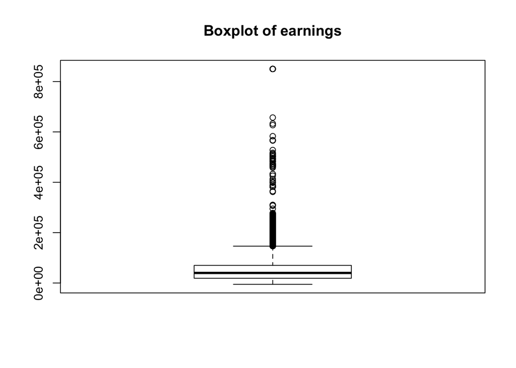

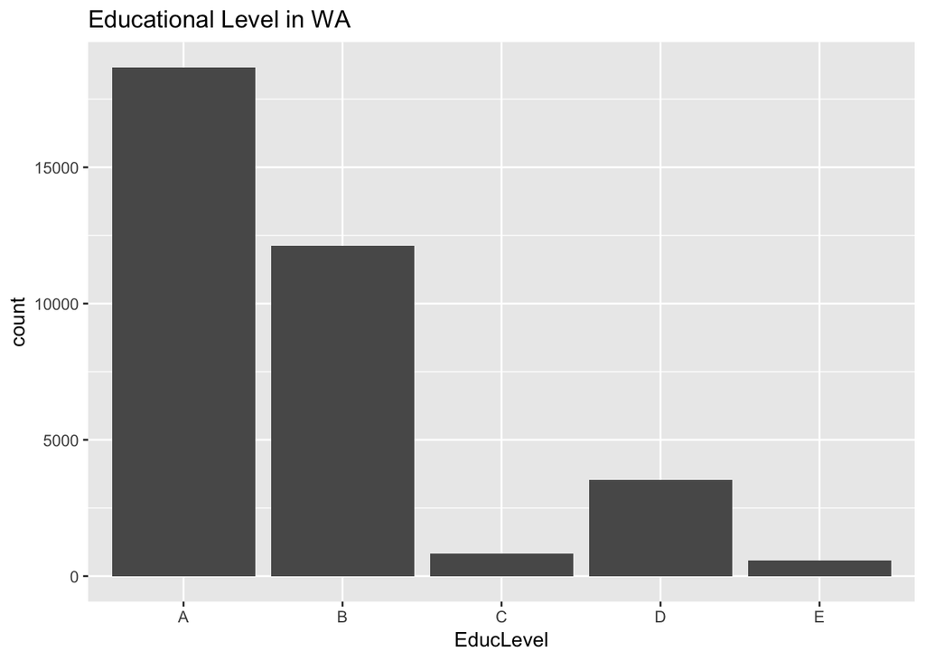

- Since it is a qualitive variable, we draw a histogram graph to explain the data set.
- From the graph, we can tell that the least number of people got doctor degree; most of the people attained high school degrees or college degrees.

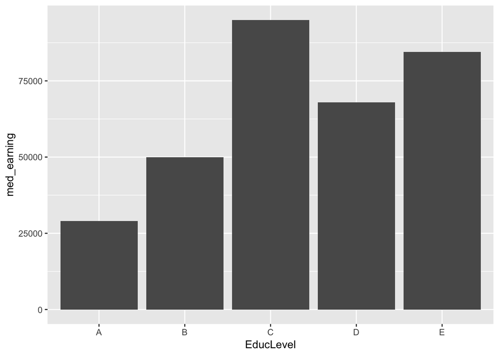

- The histogram graph shows the relationship between educational level and wages of our sample data. From the graph, we can tell that people whose education degree is no higher than high school earn least in the group; people with professional degree earn most money compared to other groups.

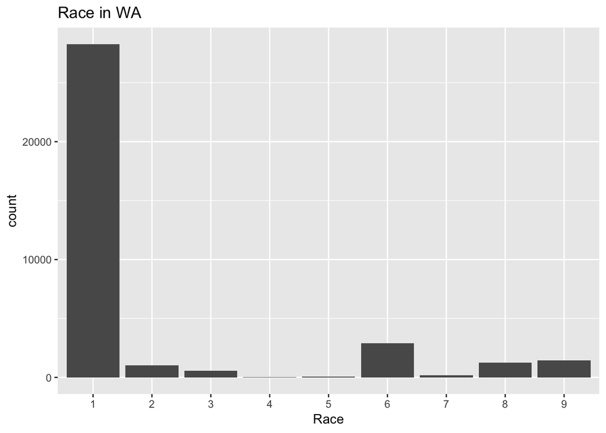

- From the graph, we can see that the majority of people in WA are white; the second largest group is Asian (alone) group; there are few Alaska Native or American Indian in WA.

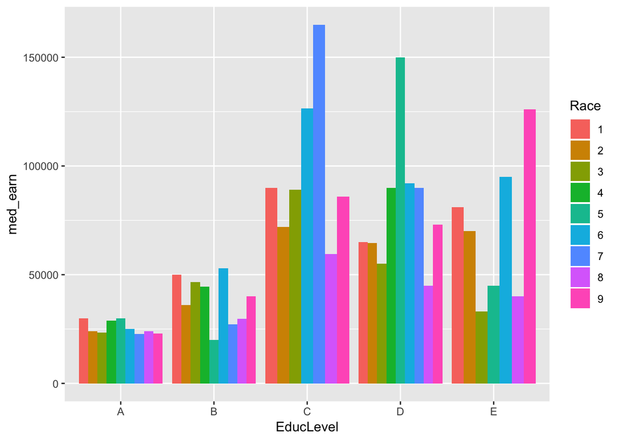

- The graph shows the relationship between wages, educational level, and races.
- We still can find that people with professional degrees earns the most.
- Different races have different advantages in earning among the 5 education levels.